# Data Preprocessing

### If the last month charges is too high or too low compared to average monthly charges, The customer tend to Churn.

```python
a = [i for i in range(0, train['tenure'].nunique())]
b = a.copy()
b.remove(0)

b.extend([0])
np.subtract(np.array(b), np.array(a))
len(train0['tenure'].unique())
train['tenure'].nunique()
```

```
72
```

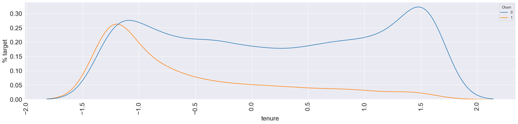

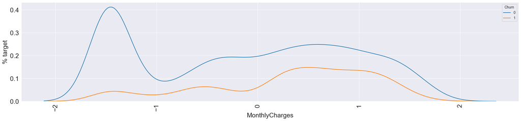

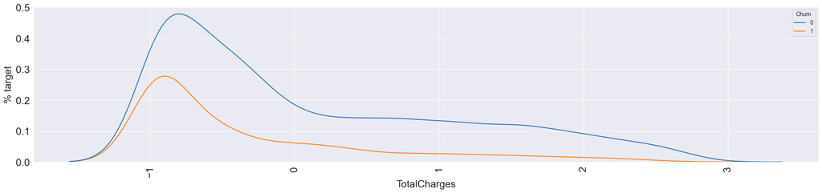

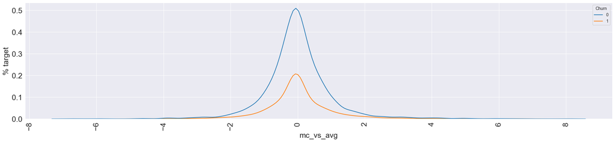

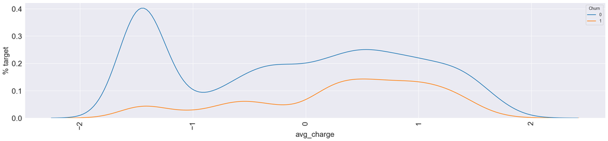

```python
interval_columns = ['tenure', 'MonthlyCharges', 'TotalCharges', 'mc_vs_avg', 'avg_charge']
for f in interval_columns:
    data = train[[f]].join(y)
    plt.figure()
    fig, ax = plt.subplots(figsize=(25, 5))
    # Calculate the percentage of target=1 per category value

    cat_perc = data[[f, 'Churn']].groupby([f], as_index=False).mean()
    cat_perc.sort_values(by='Churn', ascending=False, inplace=True)
    # Bar plot
    # Order the bars descending on target mean
    # sns.barplot(ax=ax, x=f, y='Churn', data=cat_perc, order=cat_perc[f], color='blue')
    sns.kdeplot(data=data, x=f, hue='Churn')
    plt.xticks(rotation=90)
    plt.ylabel('% target', fontsize=18)
    plt.xlabel(f, fontsize=18)
    plt.tick_params(axis='both', which='major', labelsize=18)
    plt.show()
```

```python
y.unique()
```

```
array([0, 1])
```

## Purpose-Develop meaningful feature engineering(e.g., tenure groups, service counts)

```python
train
```

|  | gender | SeniorCitizen | Partner | Dependents | tenure | PhoneService | MultipleLines | InternetService | OnlineSecurity | OnlineBackup | ... | MonthlyCharges | TotalCharges | Churn | month | avg_charge | mc_vs_avg | binned_MonthlyCharges | binned_TotalCharges | binned_mc_vs_avg | binned_avg_charge |
| --- | --- | --- | --- | --- | --- | --- | --- | --- | --- | --- | --- | --- | --- | --- | --- | --- | --- | --- | --- | --- | --- |
| 0 | Female | No | Yes | No | -1.284594 | No | No phone service | DSL | No | Yes | ... | -1.165797 | -0.996734 | 0 | 1 | -1.161962 | -0.045126 | (-1.185, -1.139] | (-1.002, -0.949] | (-0.185, 0.0329] | (-1.206, -1.157] |
| 1 | Male | No | No | No | 0.061068 | Yes | No | DSL | Yes | No | ... | -0.264112 | -0.176289 | 0 | 10 | -0.308920 | 0.437219 | (-0.269, -0.223] | (-0.216, -0.164] | (0.25, 0.468] | (-0.326, -0.277] |
| 2 | Male | No | No | No | -1.243817 | Yes | No | DSL | Yes | Yes | ... | -0.367257 | -0.962189 | 1 | 2 | -0.358615 | -0.126156 | (-0.407, -0.361] | (-1.002, -0.949] | (-0.185, 0.0329] | (-0.375, -0.326] |
| 3 | Male | No | No | No | 0.509622 | No | No phone service | DSL | Yes | No | ... | -0.751554 | -0.197797 | 0 | 9 | -0.795338 | 0.618735 | (-0.773, -0.727] | (-0.216, -0.164] | (0.468, 0.685] | (-0.815, -0.766] |
| 4 | Female | No | No | No | -1.243817 | Yes | No | Fiber optic | No | No | ... | 0.193386 | -0.942998 | 1 | 2 | 0.362657 | -1.361380 | (0.189, 0.235] | (-0.949, -0.897] | (-1.489, -1.272] | (0.358, 0.407] |
| ... | ... | ... | ... | ... | ... | ... | ... | ... | ... | ... | ... | ... | ... | ... | ... | ... | ... | ... | ... | ... | ... |
| 7038 | Male | No | Yes | Yes | -0.346709 | Yes | Yes | DSL | Yes | No | ... | 0.662528 | -0.131730 | 0 | 12 | 0.598521 | 0.392199 | (0.647, 0.693] | (-0.164, -0.111] | (0.25, 0.468] | (0.554, 0.603] |
| 7039 | Female | No | Yes | Yes | 1.610618 | Yes | Yes | Fiber optic | No | Yes | ... | 1.274743 | 2.238478 | 0 | 12 | 1.239375 | 0.133405 | (1.242, 1.288] | (2.193, 2.246] | (0.0329, 0.25] | (1.238, 1.287] |
| 7040 | Female | No | Yes | Yes | -0.876818 | No | No phone service | DSL | Yes | No | ... | -1.174115 | -0.857056 | 0 | 11 | -1.107395 | -1.217116 | (-1.185, -1.139] | (-0.897, -0.844] | (-1.272, -1.054] | (-1.108, -1.059] |
| 7041 | Male | Yes | Yes | No | -1.162261 | Yes | Yes | Fiber optic | No | No | ... | 0.316494 | -0.874637 | 1 | 4 | 0.390016 | -0.616774 | (0.281, 0.326] | (-0.897, -0.844] | (-0.619, -0.402] | (0.358, 0.407] |
| 7042 | Male | No | No | No | 1.365952 | Yes | No | Fiber optic | Yes | No | ... | 1.356261 | 2.009770 | 0 | 6 | 1.287196 | 0.320201 | (1.334, 1.38] | (1.984, 2.036] | (0.25, 0.468] | (1.238, 1.287] |

7011 rows × 27 columns

### Conclusion:

Information: tenure give information. As tenure increases, the churn rate decrease. Action: MonthlyCharges -> binned_MonthlyCharges Action: TotalCharges -> binned_TotalCharges

# Exploratory Data Analysis

## Purpose- Perform univariate analysis on key variables

### Chi-Square test for categorical features correlation

```python
print(train['binned_MonthlyCharges'])
```

```
0       (-1.185, -1.139]
1       (-0.269, -0.223]
2       (-0.407, -0.361]
3       (-0.773, -0.727]
4         (0.189, 0.235]
              ...
7038      (0.647, 0.693]
7039      (1.242, 1.288]
7040    (-1.185, -1.139]
7041      (0.281, 0.326]
7042       (1.334, 1.38]
Name: binned_MonthlyCharges, Length: 7011, dtype: category
Categories (72, interval[float64, right]): [(-1.552, -1.506] < (-1.506, -1.46] < (-1.46, -1.414] < (-1.414, -1.369] ... (1.563, 1.609] < (1.609, 1.655] < (1.655, 1.701] < (1.701, 1.746]]
```

```python
# Identify categorical features (excluding target variable)
categorical_features = [col for col in train.columns if train[col].dtype == 'O' or train[col].nunique() <= 10]

# Store results
chi2_results = []

# Perform Chi-Square test for each categorical feature
for feature in categorical_features:
    print(f"Testing feature: {feature}")

    # Create a contingency table
    contingency_table = pd.crosstab(train[feature], y)

    # Perform Chi-Square test
    chi2_stat, p_value, dof, expected = chi2_contingency(contingency_table)

    # Collect results
    chi2_results.append({
        'Feature': feature,
        'Chi2_Stat': chi2_stat,
        'p-value': p_value,
        'Degrees_of_Freedom': dof,
        'Significant': p_value < 0.05  # True if p-value < 0.05
    })

    print(f"Chi-Square Statistic: {chi2_stat}, p-value: {p_value}, Significant: {p_value < 0.05}\n")

# Convert results to a DataFrame for easy viewing
results_df = pd.DataFrame(chi2_results)

# Filter significant results
significant_features = results_df[results_df['Significant']]
print("Significant Features (p < 0.05):")
print(significant_features)
```

```
Testing feature: gender
Chi-Square Statistic: 0.5062156219588821, p-value: 0.4767816894213255, Significant: False

Testing feature: SeniorCitizen
Chi-Square Statistic: 160.10513402866923, p-value: 1.073193079735253e-36, Significant: True

Testing feature: Partner
Chi-Square Statistic: 155.28517991505026, p-value: 1.2130356962926863e-35, Significant: True

Testing feature: Dependents
Chi-Square Statistic: 184.33692924368518, p-value: 5.4771349693371126e-42, Significant: True

Testing feature: PhoneService
Chi-Square Statistic: 0.8035620385800925, p-value: 0.37003050788642045, Significant: False

Testing feature: MultipleLines
Chi-Square Statistic: 12.011745358588566, p-value: 0.0024642379205827634, Significant: True

Testing feature: InternetService
Chi-Square Statistic: 738.2754140566219, p-value: 4.847644630207988e-161, Significant: True

Testing feature: OnlineSecurity
Chi-Square Statistic: 857.1546402159107, p-value: 7.434209716515333e-187, Significant: True

Testing feature: OnlineBackup
Chi-Square Statistic: 609.3459819464206, p-value: 4.810622025549891e-133, Significant: True

Testing feature: DeviceProtection
Chi-Square Statistic: 566.0198983673617, p-value: 1.2312344138065643e-123, Significant: True

Testing feature: TechSupport
Chi-Square Statistic: 835.3742851533483, p-value: 3.988217336538509e-182, Significant: True

Testing feature: StreamingTV
Chi-Square Statistic: 382.6326915770964, p-value: 8.172721995373581e-84, Significant: True

Testing feature: StreamingMovies
Chi-Square Statistic: 384.4343348376759, p-value: 3.3200518247196693e-84, Significant: True

Testing feature: Contract
```

[output cut: 30 more lines]

```
1          True
2          True
3          True
5          True
6          True
7          True
8          True
9          True
10         True
11         True
12         True
13         True
14         True
15         True
16         True
```

### tenure

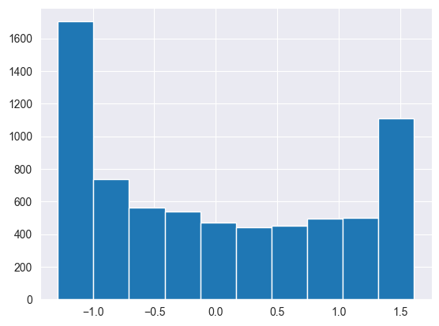

```python
plt.hist(train.tenure)
```

### month

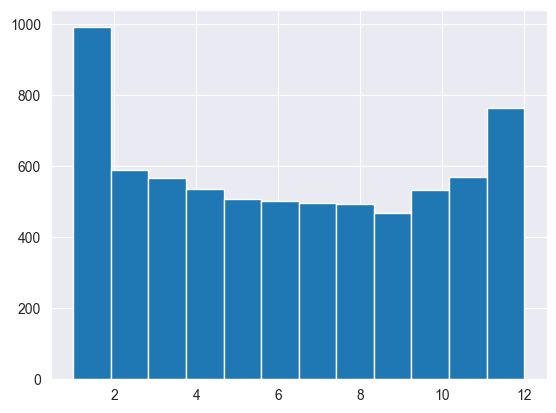

```python
plt.hist(train['month'], bins=12)
```

### binned_MonthlyCharges

```python
train['binned_MonthlyCharges'].describe()
```

```
count                7000
unique                 72
top       (-1.506, -1.46]
freq                  829
Name: binned_MonthlyCharges, dtype: object
```

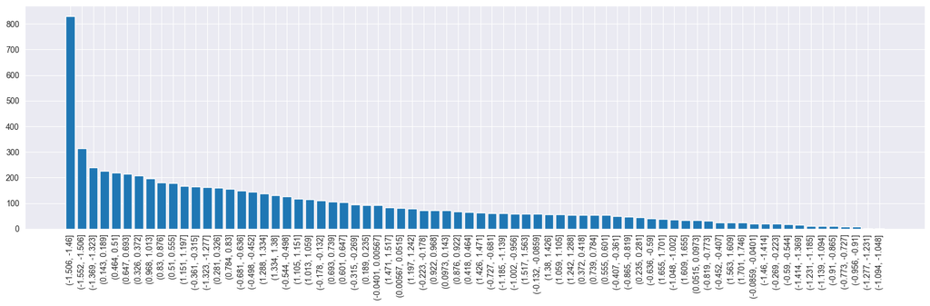

```python
a = pd.DataFrame(train['binned_MonthlyCharges'].value_counts())
a.reset_index(inplace=True)
a['binned_MonthlyCharges'] = a['binned_MonthlyCharges'].astype(str)
plt.figure(figsize=(20, 5))
plt.bar(a['binned_MonthlyCharges'], a['count'])
plt.xticks(rotation=90);
# plt.hist(train['binned_MonthlyCharges'].value_counts().sort_index(), bins=72)
```

```python
train['binned_MonthlyCharges'].value_counts().sort_index()
```

```
binned_MonthlyCharges
(-1.552, -1.506]    313
(-1.506, -1.46]     829
(-1.46, -1.414]      20
(-1.414, -1.369]     15
(-1.369, -1.323]    240
                   ...
(1.517, 1.563]       59
(1.563, 1.609]       25
(1.609, 1.655]       34
(1.655, 1.701]       39
(1.701, 1.746]       25
Name: count, Length: 72, dtype: int64
```

### binned_mc_vs_avg

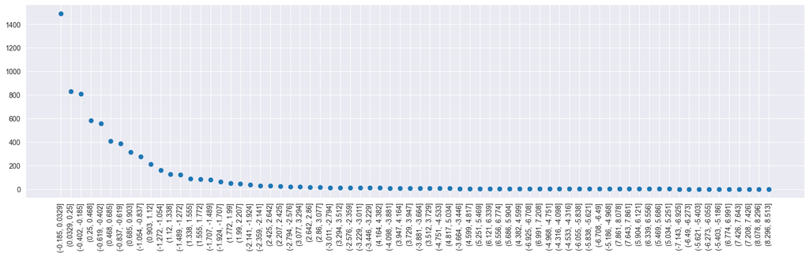

```python
a = pd.DataFrame(train['binned_mc_vs_avg'].value_counts())
a.reset_index(inplace=True)
a['binned_mc_vs_avg'] = a['binned_mc_vs_avg'].astype(str)
plt.figure(figsize=(20, 5))
# Ensure the data is sorted
# sorted_data = a.sort_values(by='binned_mc_vs_avg')  # Sort data by 'binned_mc_vs_avg'
# # Plot the data
# plt.bar(sorted_data['binned_mc_vs_avg'], sorted_data['count'])
# # Sort x-ticks
# plt.xticks(sorted_data['binned_mc_vs_avg'], sorted(sorted_data['binned_mc_vs_avg']))

plt.scatter(a['binned_mc_vs_avg'], a['count'])
plt.xticks(rotation=90);



# sns.barplot(ax=ax, x=f, y='Churn', data=cat_perc, order=cat_perc[f], color='red')

# plt.plot(train['binned_mc_vs_avg'].value_counts().sort_index())
```

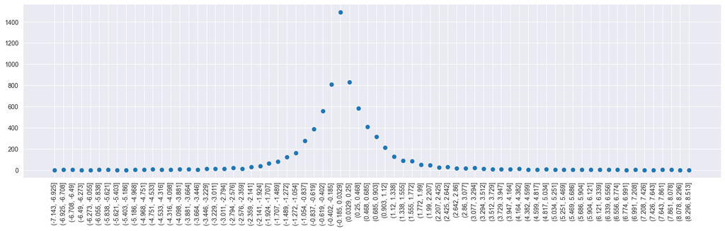

```python
df = a.copy()
df['binned_mc_vs_avg'] = pd.Categorical(
    df['binned_mc_vs_avg'],
    categories=sorted(df['binned_mc_vs_avg'].unique(), key=lambda x: float(x.split(',')[0][1:])),
    ordered=True
)
df = df.sort_values(by='binned_mc_vs_avg').reset_index(drop=True)
plt.figure(figsize=(20, 5))
plt.scatter(df['binned_mc_vs_avg'], df['count'])
plt.xticks(rotation=90);
```

### Categorical Count Bar Plot

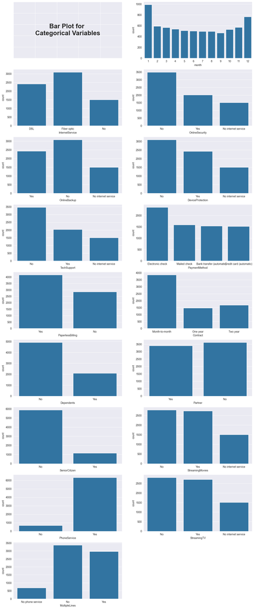

```python
cat_meaningful_list = ['month', 'InternetService', 'OnlineSecurity', 'OnlineBackup', 'DeviceProtection',
                       'TechSupport', 'PaymentMethod', 'PaperlessBilling', 'Contract', 'Dependents', 'Partner',
                       'SeniorCitizen', 'StreamingMovies', 'PhoneService', 'StreamingTV', 'MultipleLines']


def set_spines_visibility(ax, is_visible):
    for s in ['left', 'right', 'top', 'bottom']:
        ax.spines[s].set_visible(is_visible)


fig = plt.figure(figsize=(16, 250))
gs = fig.add_gridspec(55, 2)

for i in range(len(cat_meaningful_list) + 1):
    if i == 0:
        ax = fig.add_subplot(gs[0, 0])
        ax.text(x=0.5, y=0.5, s="Bar Plot for \nCategorical Variables",
                horizontalalignment='center', verticalalignment='center',
                fontweight='bold', fontsize='24')
        ax.set_xticklabels([])
        ax.set_yticklabels([])
        ax.tick_params(left=False, bottom=False)
        set_spines_visibility(ax, False)
    else:
        ax = fig.add_subplot(gs[(i) // 2, i % 2])
        sns.countplot(x=train[cat_meaningful_list[i - 1]], ax=ax)
        set_spines_visibility(ax, False)
        plt.xticks(rotation=0)
plt.show()

cat_meaningful_list.extend(['MonthlyCharges', 'mc_vs_avg'])
```

### Analyze relationships between features and churn

### Create informative visualizations with proper labeling and titles

### Conduct correlation analysis to identify significant patterns

### Conclusion-This is done in Data Preprocessing

# Model and Evaluation

## Feature Selection

```python
cat_meaningful_list
```

```
['month',
 'InternetService',
 'OnlineSecurity',
 'OnlineBackup',
 'DeviceProtection',
 'TechSupport',
 'PaymentMethod',
 'PaperlessBilling',
 'Contract',
 'Dependents',
 'Partner',
 'SeniorCitizen',
 'StreamingMovies',
 'PhoneService',
 'StreamingTV',
 'MultipleLines',
 'MonthlyCharges',
 'mc_vs_avg']
```

```python
interval_columns_bin
```

```
['tenure',
 'binned_MonthlyCharges',
 'binned_TotalCharges',
 'binned_mc_vs_avg',
 'binned_avg_charge']
```

```python
train_list = cat_meaningful_list.copy()
train_list.extend(interval_columns_bin)
train_list.remove('binned_TotalCharges')
# train_list.remove('binned_MonthlyCharges')
train_list.remove('binned_avg_charge')
train_list
```

```
['month',
 'InternetService',
 'OnlineSecurity',
 'OnlineBackup',
 'DeviceProtection',
 'TechSupport',
 'PaymentMethod',
 'PaperlessBilling',
 'Contract',
 'Dependents',
 'Partner',
 'SeniorCitizen',
 'StreamingMovies',
 'PhoneService',
 'StreamingTV',
 'MultipleLines',
 'MonthlyCharges',
 'mc_vs_avg',
 'tenure',
 'binned_MonthlyCharges',
 'binned_mc_vs_avg']
```

```python
train = train[train_list]
```

### One-hot encoding the 3-4 values variables

```python
multi_value_cat_volumns = []
for f in train.columns:
    if ((train[f].dtype == 'O' or train[f].dtype == 'category') and
            (train[f].nunique() <= 12) and (train[f].nunique() > 0)):
        multi_value_cat_volumns.append(f)
# print(multi_value_cat_volumns)

train = pd.get_dummies(train, columns=multi_value_cat_volumns)
```

```python
train.columns
```

```
Index(['MonthlyCharges', 'mc_vs_avg', 'tenure', 'binned_MonthlyCharges',
       'binned_mc_vs_avg', 'month_1', 'month_2', 'month_3', 'month_4',
       'month_5', 'month_6', 'month_7', 'month_8', 'month_9', 'month_10',
       'month_11', 'month_12', 'InternetService_DSL',
       'InternetService_Fiber optic', 'InternetService_No',
       'OnlineSecurity_No', 'OnlineSecurity_No internet service',
       'OnlineSecurity_Yes', 'OnlineBackup_No',
       'OnlineBackup_No internet service', 'OnlineBackup_Yes',
       'DeviceProtection_No', 'DeviceProtection_No internet service',
       'DeviceProtection_Yes', 'TechSupport_No',
       'TechSupport_No internet service', 'TechSupport_Yes',
       'PaymentMethod_Bank transfer (automatic)',
       'PaymentMethod_Credit card (automatic)',
       'PaymentMethod_Electronic check', 'PaymentMethod_Mailed check',
       'PaperlessBilling_No', 'PaperlessBilling_Yes',
       'Contract_Month-to-month', 'Contract_One year', 'Contract_Two year',
       'Dependents_No', 'Dependents_Yes', 'Partner_No', 'Partner_Yes',
       'SeniorCitizen_No', 'SeniorCitizen_Yes', 'StreamingMovies_No',
       'StreamingMovies_No internet service', 'StreamingMovies_Yes',
       'PhoneService_No', 'PhoneService_Yes', 'StreamingTV_No',
       'StreamingTV_No internet service', 'StreamingTV_Yes',
       'MultipleLines_No', 'MultipleLines_No phone service',
       'MultipleLines_Yes'],
      dtype='object')
```

```python
drop_list = ['InternetService_No', 'OnlineSecurity_No internet service', 'OnlineSecurity_No internet service',
             'OnlineBackup_No internet service', 'DeviceProtection_No internet service',
             'TechSupport_No internet service', 'StreamingMovies_No internet service', 'MultipleLines_No phone service',
             'StreamingTV_No internet service',
             'PaymentMethod_Credit card (automatic)', 'PaymentMethod_Bank transfer (automatic)',
             'PaymentMethod_Mailed check',
             'PaperlessBilling_No', 'Contract_Two year', 'Dependents_Yes', 'Partner_Yes', 'SeniorCitizen_No',
             'PhoneService_No', 'month_7']
train.drop(columns=drop_list, inplace=True)
```

```python
train
```

|  | MonthlyCharges | mc_vs_avg | tenure | binned_MonthlyCharges | binned_mc_vs_avg | month_1 | month_2 | month_3 | month_4 | month_5 | ... | Dependents_No | Partner_No | SeniorCitizen_Yes | StreamingMovies_No | StreamingMovies_Yes | PhoneService_Yes | StreamingTV_No | StreamingTV_Yes | MultipleLines_No | MultipleLines_Yes |
| --- | --- | --- | --- | --- | --- | --- | --- | --- | --- | --- | --- | --- | --- | --- | --- | --- | --- | --- | --- | --- | --- |
| 0 | -1.165797 | -0.045126 | -1.284594 | (-1.185, -1.139] | (-0.185, 0.0329] | True | False | False | False | False | ... | True | False | False | True | False | False | True | False | False | False |
| 1 | -0.264112 | 0.437219 | 0.061068 | (-0.269, -0.223] | (0.25, 0.468] | False | False | False | False | False | ... | True | True | False | True | False | True | True | False | True | False |
| 2 | -0.367257 | -0.126156 | -1.243817 | (-0.407, -0.361] | (-0.185, 0.0329] | False | True | False | False | False | ... | True | True | False | True | False | True | True | False | True | False |
| 3 | -0.751554 | 0.618735 | 0.509622 | (-0.773, -0.727] | (0.468, 0.685] | False | False | False | False | False | ... | True | True | False | True | False | False | True | False | False | False |
| 4 | 0.193386 | -1.361380 | -1.243817 | (0.189, 0.235] | (-1.489, -1.272] | False | True | False | False | False | ... | True | True | False | True | False | True | True | False | True | False |
| ... | ... | ... | ... | ... | ... | ... | ... | ... | ... | ... | ... | ... | ... | ... | ... | ... | ... | ... | ... | ... | ... |
| 7038 | 0.662528 | 0.392199 | -0.346709 | (0.647, 0.693] | (0.25, 0.468] | False | False | False | False | False | ... | False | False | False | False | True | True | False | True | False | True |
| 7039 | 1.274743 | 0.133405 | 1.610618 | (1.242, 1.288] | (0.0329, 0.25] | False | False | False | False | False | ... | False | False | False | False | True | True | False | True | False | True |
| 7040 | -1.174115 | -1.217116 | -0.876818 | (-1.185, -1.139] | (-1.272, -1.054] | False | False | False | False | False | ... | False | False | False | True | False | False | True | False | False | False |
| 7041 | 0.316494 | -0.616774 | -1.162261 | (0.281, 0.326] | (-0.619, -0.402] | False | False | False | True | False | ... | True | False | True | True | False | True | True | False | False | True |
| 7042 | 1.356261 | 0.320201 | 1.365952 | (1.334, 1.38] | (0.25, 0.468] | False | False | False | False | False | ... | True | True | False | False | True | True | False | True | True | False |

7011 rows × 40 columns

### The dictionary for category translation

```python
translation_dict = {}
```

### If need to convert two value category to binary 0/1 column

```python
for f in train.columns:
    if (train[f].dtype == 'O' or train[f].dtype == 'bool') and (train[f].nunique() == 2):
        translation_dict[f] = {train[f].unique()[0]: 0, train[f].unique()[1]: 1}
        train[f] = train[f].map({train[f].unique()[0]: 0, train[f].unique()[1]: 1})
```

```python
translation_dict
```

```
{'month_1': {np.True_: 0, np.False_: 1},
 'month_2': {np.False_: 0, np.True_: 1},
 'month_3': {np.False_: 0, np.True_: 1},
 'month_4': {np.False_: 0, np.True_: 1},
 'month_5': {np.False_: 0, np.True_: 1},
 'month_6': {np.False_: 0, np.True_: 1},
 'month_8': {np.False_: 0, np.True_: 1},
 'month_9': {np.False_: 0, np.True_: 1},
 'month_10': {np.False_: 0, np.True_: 1},
 'month_11': {np.False_: 0, np.True_: 1},
 'month_12': {np.False_: 0, np.True_: 1},
 'InternetService_DSL': {np.True_: 0, np.False_: 1},
 'InternetService_Fiber optic': {np.False_: 0, np.True_: 1},
 'OnlineSecurity_No': {np.True_: 0, np.False_: 1},
 'OnlineSecurity_Yes': {np.False_: 0, np.True_: 1},
 'OnlineBackup_No': {np.False_: 0, np.True_: 1},
 'OnlineBackup_Yes': {np.True_: 0, np.False_: 1},
 'DeviceProtection_No': {np.True_: 0, np.False_: 1},
 'DeviceProtection_Yes': {np.False_: 0, np.True_: 1},
 'TechSupport_No': {np.True_: 0, np.False_: 1},
 'TechSupport_Yes': {np.False_: 0, np.True_: 1},
 'PaymentMethod_Electronic check': {np.True_: 0, np.False_: 1},
 'PaperlessBilling_Yes': {np.True_: 0, np.False_: 1},
 'Contract_Month-to-month': {np.True_: 0, np.False_: 1},
 'Contract_One year': {np.False_: 0, np.True_: 1},
 'Dependents_No': {np.True_: 0, np.False_: 1},
 'Partner_No': {np.False_: 0, np.True_: 1},
 'SeniorCitizen_Yes': {np.False_: 0, np.True_: 1},
 'StreamingMovies_No': {np.True_: 0, np.False_: 1},
 'StreamingMovies_Yes': {np.False_: 0, np.True_: 1},
 'PhoneService_Yes': {np.False_: 0, np.True_: 1},
 'StreamingTV_No': {np.True_: 0, np.False_: 1},
 'StreamingTV_Yes': {np.False_: 0, np.True_: 1},
 'MultipleLines_No': {np.False_: 0, np.True_: 1},
 'MultipleLines_Yes': {np.False_: 0, np.True_: 1}}
```

### reverse dict for translating from int to object

```python
translation_dict_reverse = {}
for feat_key in translation_dict:
    translation_dict_reverse[feat_key] = {value: key for key, value in translation_dict[feat_key].items()}
translation_dict_reverse
```

```
{'month_1': {0: np.True_, 1: np.False_},
 'month_2': {0: np.False_, 1: np.True_},
 'month_3': {0: np.False_, 1: np.True_},
 'month_4': {0: np.False_, 1: np.True_},
 'month_5': {0: np.False_, 1: np.True_},
 'month_6': {0: np.False_, 1: np.True_},
 'month_8': {0: np.False_, 1: np.True_},
 'month_9': {0: np.False_, 1: np.True_},
 'month_10': {0: np.False_, 1: np.True_},
 'month_11': {0: np.False_, 1: np.True_},
 'month_12': {0: np.False_, 1: np.True_},
 'InternetService_DSL': {0: np.True_, 1: np.False_},
 'InternetService_Fiber optic': {0: np.False_, 1: np.True_},
 'OnlineSecurity_No': {0: np.True_, 1: np.False_},
 'OnlineSecurity_Yes': {0: np.False_, 1: np.True_},
 'OnlineBackup_No': {0: np.False_, 1: np.True_},
 'OnlineBackup_Yes': {0: np.True_, 1: np.False_},
 'DeviceProtection_No': {0: np.True_, 1: np.False_},
 'DeviceProtection_Yes': {0: np.False_, 1: np.True_},
 'TechSupport_No': {0: np.True_, 1: np.False_},
 'TechSupport_Yes': {0: np.False_, 1: np.True_},
 'PaymentMethod_Electronic check': {0: np.True_, 1: np.False_},
 'PaperlessBilling_Yes': {0: np.True_, 1: np.False_},
 'Contract_Month-to-month': {0: np.True_, 1: np.False_},
 'Contract_One year': {0: np.False_, 1: np.True_},
 'Dependents_No': {0: np.True_, 1: np.False_},
 'Partner_No': {0: np.False_, 1: np.True_},
 'SeniorCitizen_Yes': {0: np.False_, 1: np.True_},
 'StreamingMovies_No': {0: np.True_, 1: np.False_},
 'StreamingMovies_Yes': {0: np.False_, 1: np.True_},
 'PhoneService_Yes': {0: np.False_, 1: np.True_},
 'StreamingTV_No': {0: np.True_, 1: np.False_},
 'StreamingTV_Yes': {0: np.False_, 1: np.True_},
 'MultipleLines_No': {0: np.False_, 1: np.True_},
 'MultipleLines_Yes': {0: np.False_, 1: np.True_}}
```

```python
for f in train.columns:
    # print(train[f].nunique())
    print(f, '\t\t', train[f].dtype, '\t\t', train[f].nunique(), '\t', end="")
    if train[f].unique().size <= 12:
        print(f"{train[f].unique()}")
    else:
        print(f"[]")
```

```
MonthlyCharges 		 float64 		 1584 	[]
mc_vs_avg 		 float64 		 6411 	[]
tenure 		 float64 		 72 	[]
binned_MonthlyCharges 		 category 		 72 	[]
binned_mc_vs_avg 		 category 		 62 	[]
month_1 		 int64 		 2 	[0 1]
month_2 		 int64 		 2 	[0 1]
month_3 		 int64 		 2 	[0 1]
month_4 		 int64 		 2 	[0 1]
month_5 		 int64 		 2 	[0 1]
month_6 		 int64 		 2 	[0 1]
month_8 		 int64 		 2 	[0 1]
month_9 		 int64 		 2 	[0 1]
month_10 		 int64 		 2 	[0 1]
month_11 		 int64 		 2 	[0 1]
month_12 		 int64 		 2 	[0 1]
InternetService_DSL 		 int64 		 2 	[0 1]
InternetService_Fiber optic 		 int64 		 2 	[0 1]
OnlineSecurity_No 		 int64 		 2 	[0 1]
OnlineSecurity_Yes 		 int64 		 2 	[0 1]
OnlineBackup_No 		 int64 		 2 	[0 1]
OnlineBackup_Yes 		 int64 		 2 	[0 1]
DeviceProtection_No 		 int64 		 2 	[0 1]
DeviceProtection_Yes 		 int64 		 2 	[0 1]
TechSupport_No 		 int64 		 2 	[0 1]
TechSupport_Yes 		 int64 		 2 	[0 1]
PaymentMethod_Electronic check 		 int64 		 2 	[0 1]
PaperlessBilling_Yes 		 int64 		 2 	[0 1]
Contract_Month-to-month 		 int64 		 2 	[0 1]
Contract_One year 		 int64 		 2 	[0 1]
Dependents_No 		 int64 		 2 	[0 1]
Partner_No 		 int64 		 2 	[0 1]
SeniorCitizen_Yes 		 int64 		 2 	[0 1]
StreamingMovies_No 		 int64 		 2 	[0 1]
StreamingMovies_Yes 		 int64 		 2 	[0 1]
PhoneService_Yes 		 int64 		 2 	[0 1]
StreamingTV_No 		 int64 		 2 	[0 1]
StreamingTV_Yes 		 int64 		 2 	[0 1]
MultipleLines_No 		 int64 		 2 	[0 1]
MultipleLines_Yes 		 int64 		 2 	[0 1]
```

```python
# object_columns = train.select_dtypes(include=['object']).columns
# len(object_columns)
```

### Convert group to midpoint

```python
dup_list = train.duplicated()
dup_list.sum()
```

```
np.int64(59)
```

```python
train_y = train.join(y)
```

```python
total_dup_list = train_y.duplicated()
total_dup_list.sum()
```

```
np.int64(45)
```

```python
conflict_list = dup_list & ~total_dup_list
conflict_list.sum()
```

```
np.int64(14)
```

### I think it's not proper to drop these rows. Because the conflic is caused by data preprocessing.

```python
# train_y.drop(train[conflict_list].index, inplace=True)
```

```python
y = train_y['Churn']
train = train_y.drop(columns=['Churn'])
train
```

|  | MonthlyCharges | mc_vs_avg | tenure | binned_MonthlyCharges | binned_mc_vs_avg | month_1 | month_2 | month_3 | month_4 | month_5 | ... | Dependents_No | Partner_No | SeniorCitizen_Yes | StreamingMovies_No | StreamingMovies_Yes | PhoneService_Yes | StreamingTV_No | StreamingTV_Yes | MultipleLines_No | MultipleLines_Yes |
| --- | --- | --- | --- | --- | --- | --- | --- | --- | --- | --- | --- | --- | --- | --- | --- | --- | --- | --- | --- | --- | --- |
| 0 | -1.165797 | -0.045126 | -1.284594 | (-1.185, -1.139] | (-0.185, 0.0329] | 0 | 0 | 0 | 0 | 0 | ... | 0 | 0 | 0 | 0 | 0 | 0 | 0 | 0 | 0 | 0 |
| 1 | -0.264112 | 0.437219 | 0.061068 | (-0.269, -0.223] | (0.25, 0.468] | 1 | 0 | 0 | 0 | 0 | ... | 0 | 1 | 0 | 0 | 0 | 1 | 0 | 0 | 1 | 0 |
| 2 | -0.367257 | -0.126156 | -1.243817 | (-0.407, -0.361] | (-0.185, 0.0329] | 1 | 1 | 0 | 0 | 0 | ... | 0 | 1 | 0 | 0 | 0 | 1 | 0 | 0 | 1 | 0 |
| 3 | -0.751554 | 0.618735 | 0.509622 | (-0.773, -0.727] | (0.468, 0.685] | 1 | 0 | 0 | 0 | 0 | ... | 0 | 1 | 0 | 0 | 0 | 0 | 0 | 0 | 0 | 0 |
| 4 | 0.193386 | -1.361380 | -1.243817 | (0.189, 0.235] | (-1.489, -1.272] | 1 | 1 | 0 | 0 | 0 | ... | 0 | 1 | 0 | 0 | 0 | 1 | 0 | 0 | 1 | 0 |
| ... | ... | ... | ... | ... | ... | ... | ... | ... | ... | ... | ... | ... | ... | ... | ... | ... | ... | ... | ... | ... | ... |
| 7038 | 0.662528 | 0.392199 | -0.346709 | (0.647, 0.693] | (0.25, 0.468] | 1 | 0 | 0 | 0 | 0 | ... | 1 | 0 | 0 | 1 | 1 | 1 | 1 | 1 | 0 | 1 |
| 7039 | 1.274743 | 0.133405 | 1.610618 | (1.242, 1.288] | (0.0329, 0.25] | 1 | 0 | 0 | 0 | 0 | ... | 1 | 0 | 0 | 1 | 1 | 1 | 1 | 1 | 0 | 1 |
| 7040 | -1.174115 | -1.217116 | -0.876818 | (-1.185, -1.139] | (-1.272, -1.054] | 1 | 0 | 0 | 0 | 0 | ... | 1 | 0 | 0 | 0 | 0 | 0 | 0 | 0 | 0 | 0 |
| 7041 | 0.316494 | -0.616774 | -1.162261 | (0.281, 0.326] | (-0.619, -0.402] | 1 | 0 | 0 | 1 | 0 | ... | 0 | 0 | 1 | 0 | 0 | 1 | 0 | 0 | 0 | 1 |
| 7042 | 1.356261 | 0.320201 | 1.365952 | (1.334, 1.38] | (0.25, 0.468] | 1 | 0 | 0 | 0 | 0 | ... | 0 | 1 | 0 | 1 | 1 | 1 | 1 | 1 | 1 | 0 |

7011 rows × 40 columns

### encode the service count to represent number of service

```python
service_count_list = ['OnlineSecurity_Yes', 'OnlineBackup_Yes', 'DeviceProtection_Yes', 'TechSupport_Yes',
                      'StreamingMovies_Yes', 'MultipleLines_Yes', 'InternetService_DSL',
                      'InternetService_Fiber optic']
train['serviceCount'] = train[service_count_list].sum(axis=1)
train
```

|  | MonthlyCharges | mc_vs_avg | tenure | binned_MonthlyCharges | binned_mc_vs_avg | month_1 | month_2 | month_3 | month_4 | month_5 | ... | Partner_No | SeniorCitizen_Yes | StreamingMovies_No | StreamingMovies_Yes | PhoneService_Yes | StreamingTV_No | StreamingTV_Yes | MultipleLines_No | MultipleLines_Yes | serviceCount |
| --- | --- | --- | --- | --- | --- | --- | --- | --- | --- | --- | --- | --- | --- | --- | --- | --- | --- | --- | --- | --- | --- |
| 0 | -1.165797 | -0.045126 | -1.284594 | (-1.185, -1.139] | (-0.185, 0.0329] | 0 | 0 | 0 | 0 | 0 | ... | 0 | 0 | 0 | 0 | 0 | 0 | 0 | 0 | 0 | 0 |
| 1 | -0.264112 | 0.437219 | 0.061068 | (-0.269, -0.223] | (0.25, 0.468] | 1 | 0 | 0 | 0 | 0 | ... | 1 | 0 | 0 | 0 | 1 | 0 | 0 | 1 | 0 | 3 |
| 2 | -0.367257 | -0.126156 | -1.243817 | (-0.407, -0.361] | (-0.185, 0.0329] | 1 | 1 | 0 | 0 | 0 | ... | 1 | 0 | 0 | 0 | 1 | 0 | 0 | 1 | 0 | 1 |
| 3 | -0.751554 | 0.618735 | 0.509622 | (-0.773, -0.727] | (0.468, 0.685] | 1 | 0 | 0 | 0 | 0 | ... | 1 | 0 | 0 | 0 | 0 | 0 | 0 | 0 | 0 | 4 |
| 4 | 0.193386 | -1.361380 | -1.243817 | (0.189, 0.235] | (-1.489, -1.272] | 1 | 1 | 0 | 0 | 0 | ... | 1 | 0 | 0 | 0 | 1 | 0 | 0 | 1 | 0 | 3 |
| ... | ... | ... | ... | ... | ... | ... | ... | ... | ... | ... | ... | ... | ... | ... | ... | ... | ... | ... | ... | ... | ... |
| 7038 | 0.662528 | 0.392199 | -0.346709 | (0.647, 0.693] | (0.25, 0.468] | 1 | 0 | 0 | 0 | 0 | ... | 0 | 0 | 1 | 1 | 1 | 1 | 1 | 0 | 1 | 6 |
| 7039 | 1.274743 | 0.133405 | 1.610618 | (1.242, 1.288] | (0.0329, 0.25] | 1 | 0 | 0 | 0 | 0 | ... | 0 | 0 | 1 | 1 | 1 | 1 | 1 | 0 | 1 | 5 |
| 7040 | -1.174115 | -1.217116 | -0.876818 | (-1.185, -1.139] | (-1.272, -1.054] | 1 | 0 | 0 | 0 | 0 | ... | 0 | 0 | 0 | 0 | 0 | 0 | 0 | 0 | 0 | 2 |
| 7041 | 0.316494 | -0.616774 | -1.162261 | (0.281, 0.326] | (-0.619, -0.402] | 1 | 0 | 0 | 1 | 0 | ... | 0 | 1 | 0 | 0 | 1 | 0 | 0 | 0 | 1 | 4 |
| 7042 | 1.356261 | 0.320201 | 1.365952 | (1.334, 1.38] | (0.25, 0.468] | 1 | 0 | 0 | 0 | 0 | ... | 1 | 0 | 1 | 1 | 1 | 1 | 1 | 1 | 0 | 7 |

7011 rows × 41 columns

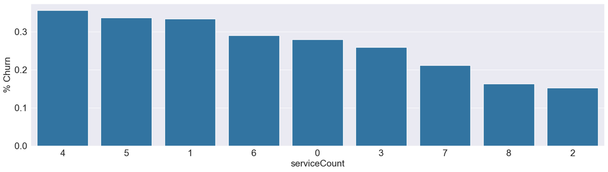

```python
train['Churn'] = y

for f in ['serviceCount']:
    plt.figure()
    fig, ax = plt.subplots(figsize=(20, 5))
    # Calculate the percentage of target=1 per category value

    cat_perc = train[[f, 'Churn']].groupby([f], as_index=False).mean()
    cat_perc.sort_values(by='Churn', ascending=False, inplace=True)
    # Bar plot
    # Order the bars descending on target mean
    sns.barplot(ax=ax, x=f, y='Churn', data=cat_perc, order=cat_perc[f])
    plt.ylabel('% Churn', fontsize=18)
    plt.xlabel(f, fontsize=18)
    plt.tick_params(axis='both', which='major', labelsize=18)
    plt.show()
```

```python
train['serviceCount'] = train['serviceCount'].astype('category')
```

### service count vs monthly charges

```python
print(train.columns)
```

```
Index(['MonthlyCharges', 'mc_vs_avg', 'tenure', 'binned_MonthlyCharges',
       'binned_mc_vs_avg', 'month_1', 'month_2', 'month_3', 'month_4',
       'month_5', 'month_6', 'month_8', 'month_9', 'month_10', 'month_11',
       'month_12', 'InternetService_DSL', 'InternetService_Fiber optic',
       'OnlineSecurity_No', 'OnlineSecurity_Yes', 'OnlineBackup_No',
       'OnlineBackup_Yes', 'DeviceProtection_No', 'DeviceProtection_Yes',
       'TechSupport_No', 'TechSupport_Yes', 'PaymentMethod_Electronic check',
       'PaperlessBilling_Yes', 'Contract_Month-to-month', 'Contract_One year',
       'Dependents_No', 'Partner_No', 'SeniorCitizen_Yes',
       'StreamingMovies_No', 'StreamingMovies_Yes', 'PhoneService_Yes',
       'StreamingTV_No', 'StreamingTV_Yes', 'MultipleLines_No',
       'MultipleLines_Yes', 'serviceCount', 'Churn'],
      dtype='object')
```

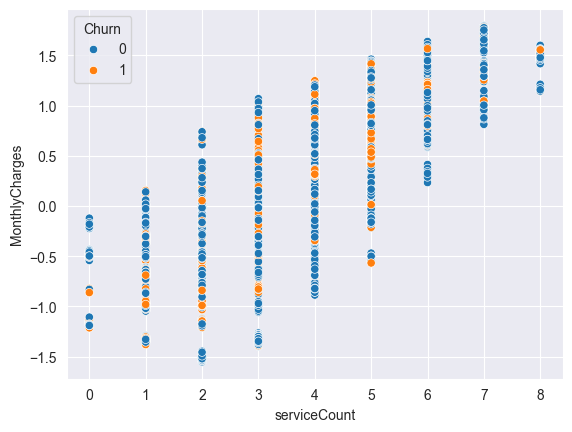

```python
sns.scatterplot(x='serviceCount', y='MonthlyCharges', hue='Churn', data=train)
```

```python
train
```

|  | MonthlyCharges | mc_vs_avg | tenure | binned_MonthlyCharges | binned_mc_vs_avg | month_1 | month_2 | month_3 | month_4 | month_5 | ... | SeniorCitizen_Yes | StreamingMovies_No | StreamingMovies_Yes | PhoneService_Yes | StreamingTV_No | StreamingTV_Yes | MultipleLines_No | MultipleLines_Yes | serviceCount | Churn |
| --- | --- | --- | --- | --- | --- | --- | --- | --- | --- | --- | --- | --- | --- | --- | --- | --- | --- | --- | --- | --- | --- |
| 0 | -1.165797 | -0.045126 | -1.284594 | (-1.185, -1.139] | (-0.185, 0.0329] | 0 | 0 | 0 | 0 | 0 | ... | 0 | 0 | 0 | 0 | 0 | 0 | 0 | 0 | 0 | 0 |
| 1 | -0.264112 | 0.437219 | 0.061068 | (-0.269, -0.223] | (0.25, 0.468] | 1 | 0 | 0 | 0 | 0 | ... | 0 | 0 | 0 | 1 | 0 | 0 | 1 | 0 | 3 | 0 |
| 2 | -0.367257 | -0.126156 | -1.243817 | (-0.407, -0.361] | (-0.185, 0.0329] | 1 | 1 | 0 | 0 | 0 | ... | 0 | 0 | 0 | 1 | 0 | 0 | 1 | 0 | 1 | 1 |
| 3 | -0.751554 | 0.618735 | 0.509622 | (-0.773, -0.727] | (0.468, 0.685] | 1 | 0 | 0 | 0 | 0 | ... | 0 | 0 | 0 | 0 | 0 | 0 | 0 | 0 | 4 | 0 |
| 4 | 0.193386 | -1.361380 | -1.243817 | (0.189, 0.235] | (-1.489, -1.272] | 1 | 1 | 0 | 0 | 0 | ... | 0 | 0 | 0 | 1 | 0 | 0 | 1 | 0 | 3 | 1 |
| ... | ... | ... | ... | ... | ... | ... | ... | ... | ... | ... | ... | ... | ... | ... | ... | ... | ... | ... | ... | ... | ... |
| 7038 | 0.662528 | 0.392199 | -0.346709 | (0.647, 0.693] | (0.25, 0.468] | 1 | 0 | 0 | 0 | 0 | ... | 0 | 1 | 1 | 1 | 1 | 1 | 0 | 1 | 6 | 0 |
| 7039 | 1.274743 | 0.133405 | 1.610618 | (1.242, 1.288] | (0.0329, 0.25] | 1 | 0 | 0 | 0 | 0 | ... | 0 | 1 | 1 | 1 | 1 | 1 | 0 | 1 | 5 | 0 |
| 7040 | -1.174115 | -1.217116 | -0.876818 | (-1.185, -1.139] | (-1.272, -1.054] | 1 | 0 | 0 | 0 | 0 | ... | 0 | 0 | 0 | 0 | 0 | 0 | 0 | 0 | 2 | 0 |
| 7041 | 0.316494 | -0.616774 | -1.162261 | (0.281, 0.326] | (-0.619, -0.402] | 1 | 0 | 0 | 1 | 0 | ... | 1 | 0 | 0 | 1 | 0 | 0 | 0 | 1 | 4 | 1 |
| 7042 | 1.356261 | 0.320201 | 1.365952 | (1.334, 1.38] | (0.25, 0.468] | 1 | 0 | 0 | 0 | 0 | ... | 0 | 1 | 1 | 1 | 1 | 1 | 1 | 0 | 7 | 0 |

7011 rows × 42 columns

## prepare the train set and target

```python
y = train['Churn']
train.drop('Churn', inplace=True, axis=1)
train
```

|  | MonthlyCharges | mc_vs_avg | tenure | binned_MonthlyCharges | binned_mc_vs_avg | month_1 | month_2 | month_3 | month_4 | month_5 | ... | Partner_No | SeniorCitizen_Yes | StreamingMovies_No | StreamingMovies_Yes | PhoneService_Yes | StreamingTV_No | StreamingTV_Yes | MultipleLines_No | MultipleLines_Yes | serviceCount |
| --- | --- | --- | --- | --- | --- | --- | --- | --- | --- | --- | --- | --- | --- | --- | --- | --- | --- | --- | --- | --- | --- |
| 0 | -1.165797 | -0.045126 | -1.284594 | (-1.185, -1.139] | (-0.185, 0.0329] | 0 | 0 | 0 | 0 | 0 | ... | 0 | 0 | 0 | 0 | 0 | 0 | 0 | 0 | 0 | 0 |
| 1 | -0.264112 | 0.437219 | 0.061068 | (-0.269, -0.223] | (0.25, 0.468] | 1 | 0 | 0 | 0 | 0 | ... | 1 | 0 | 0 | 0 | 1 | 0 | 0 | 1 | 0 | 3 |
| 2 | -0.367257 | -0.126156 | -1.243817 | (-0.407, -0.361] | (-0.185, 0.0329] | 1 | 1 | 0 | 0 | 0 | ... | 1 | 0 | 0 | 0 | 1 | 0 | 0 | 1 | 0 | 1 |
| 3 | -0.751554 | 0.618735 | 0.509622 | (-0.773, -0.727] | (0.468, 0.685] | 1 | 0 | 0 | 0 | 0 | ... | 1 | 0 | 0 | 0 | 0 | 0 | 0 | 0 | 0 | 4 |
| 4 | 0.193386 | -1.361380 | -1.243817 | (0.189, 0.235] | (-1.489, -1.272] | 1 | 1 | 0 | 0 | 0 | ... | 1 | 0 | 0 | 0 | 1 | 0 | 0 | 1 | 0 | 3 |
| ... | ... | ... | ... | ... | ... | ... | ... | ... | ... | ... | ... | ... | ... | ... | ... | ... | ... | ... | ... | ... | ... |
| 7038 | 0.662528 | 0.392199 | -0.346709 | (0.647, 0.693] | (0.25, 0.468] | 1 | 0 | 0 | 0 | 0 | ... | 0 | 0 | 1 | 1 | 1 | 1 | 1 | 0 | 1 | 6 |
| 7039 | 1.274743 | 0.133405 | 1.610618 | (1.242, 1.288] | (0.0329, 0.25] | 1 | 0 | 0 | 0 | 0 | ... | 0 | 0 | 1 | 1 | 1 | 1 | 1 | 0 | 1 | 5 |
| 7040 | -1.174115 | -1.217116 | -0.876818 | (-1.185, -1.139] | (-1.272, -1.054] | 1 | 0 | 0 | 0 | 0 | ... | 0 | 0 | 0 | 0 | 0 | 0 | 0 | 0 | 0 | 2 |
| 7041 | 0.316494 | -0.616774 | -1.162261 | (0.281, 0.326] | (-0.619, -0.402] | 1 | 0 | 0 | 1 | 0 | ... | 0 | 1 | 0 | 0 | 1 | 0 | 0 | 0 | 1 | 4 |
| 7042 | 1.356261 | 0.320201 | 1.365952 | (1.334, 1.38] | (0.25, 0.468] | 1 | 0 | 0 | 0 | 0 | ... | 1 | 0 | 1 | 1 | 1 | 1 | 1 | 1 | 0 | 7 |

7011 rows × 41 columns

```python
for col in ['binned_mc_vs_avg']:
    train[col] = train[col].apply(lambda x: x.mid)  # Convert intervals to their midpoint
```

```python
train.head()
```

|  | MonthlyCharges | mc_vs_avg | tenure | binned_MonthlyCharges | binned_mc_vs_avg | month_1 | month_2 | month_3 | month_4 | month_5 | ... | Partner_No | SeniorCitizen_Yes | StreamingMovies_No | StreamingMovies_Yes | PhoneService_Yes | StreamingTV_No | StreamingTV_Yes | MultipleLines_No | MultipleLines_Yes | serviceCount |
| --- | --- | --- | --- | --- | --- | --- | --- | --- | --- | --- | --- | --- | --- | --- | --- | --- | --- | --- | --- | --- | --- |
| 0 | -1.165797 | -0.045126 | -1.284594 | (-1.185, -1.139] | -0.07605 | 0 | 0 | 0 | 0 | 0 | ... | 0 | 0 | 0 | 0 | 0 | 0 | 0 | 0 | 0 | 0 |
| 1 | -0.264112 | 0.437219 | 0.061068 | (-0.269, -0.223] | 0.35900 | 1 | 0 | 0 | 0 | 0 | ... | 1 | 0 | 0 | 0 | 1 | 0 | 0 | 1 | 0 | 3 |
| 2 | -0.367257 | -0.126156 | -1.243817 | (-0.407, -0.361] | -0.07605 | 1 | 1 | 0 | 0 | 0 | ... | 1 | 0 | 0 | 0 | 1 | 0 | 0 | 1 | 0 | 1 |
| 3 | -0.751554 | 0.618735 | 0.509622 | (-0.773, -0.727] | 0.57650 | 1 | 0 | 0 | 0 | 0 | ... | 1 | 0 | 0 | 0 | 0 | 0 | 0 | 0 | 0 | 4 |
| 4 | 0.193386 | -1.361380 | -1.243817 | (0.189, 0.235] | -1.38050 | 1 | 1 | 0 | 0 | 0 | ... | 1 | 0 | 0 | 0 | 1 | 0 | 0 | 1 | 0 | 3 |

5 rows × 41 columns

```python
for col in train.columns:
    if train[col].dtype != 'float64':
        train[col] = train[col].astype('category')
```

```python
train.columns
```

```
Index(['MonthlyCharges', 'mc_vs_avg', 'tenure', 'binned_MonthlyCharges',
       'binned_mc_vs_avg', 'month_1', 'month_2', 'month_3', 'month_4',
       'month_5', 'month_6', 'month_8', 'month_9', 'month_10', 'month_11',
       'month_12', 'InternetService_DSL', 'InternetService_Fiber optic',
       'OnlineSecurity_No', 'OnlineSecurity_Yes', 'OnlineBackup_No',
       'OnlineBackup_Yes', 'DeviceProtection_No', 'DeviceProtection_Yes',
       'TechSupport_No', 'TechSupport_Yes', 'PaymentMethod_Electronic check',
       'PaperlessBilling_Yes', 'Contract_Month-to-month', 'Contract_One year',
       'Dependents_No', 'Partner_No', 'SeniorCitizen_Yes',
       'StreamingMovies_No', 'StreamingMovies_Yes', 'PhoneService_Yes',
       'StreamingTV_No', 'StreamingTV_Yes', 'MultipleLines_No',
       'MultipleLines_Yes', 'serviceCount'],
      dtype='object')
```

### binned_MonthlyCharges is useless or even worse. Drop it.

```python
train.drop(['binned_MonthlyCharges', 'MonthlyCharges', 'mc_vs_avg', 'serviceCount'], inplace=True, axis=1)
```

```python
y = y.astype('int')
```

```python
train_y = train.copy()
train_y.columns
```

```
Index(['tenure', 'binned_mc_vs_avg', 'month_1', 'month_2', 'month_3',
       'month_4', 'month_5', 'month_6', 'month_8', 'month_9', 'month_10',
       'month_11', 'month_12', 'InternetService_DSL',
       'InternetService_Fiber optic', 'OnlineSecurity_No',
       'OnlineSecurity_Yes', 'OnlineBackup_No', 'OnlineBackup_Yes',
       'DeviceProtection_No', 'DeviceProtection_Yes', 'TechSupport_No',
       'TechSupport_Yes', 'PaymentMethod_Electronic check',
       'PaperlessBilling_Yes', 'Contract_Month-to-month', 'Contract_One year',
       'Dependents_No', 'Partner_No', 'SeniorCitizen_Yes',
       'StreamingMovies_No', 'StreamingMovies_Yes', 'PhoneService_Yes',
       'StreamingTV_No', 'StreamingTV_Yes', 'MultipleLines_No',
       'MultipleLines_Yes'],
      dtype='object')
```

```python
# train_y.drop(['avg_charge', 'TotalCharges', 'MonthlyCharges', 'mc_vs_avg', 'tenure'], inplace=True, axis=1)
# dup_list = train_y.duplicated()
# print(dup_list.sum())
# train_y = train.join(y).copy()
# total_dup_list = train_y.duplicated()
# print(total_dup_list.sum())
# conflict_list = dup_list & ~total_dup_list
# print(conflict_list.sum())
# train_y.drop(train[conflict_list].index, inplace=True)
# y = train_y['Churn']
# train = train_y.drop(columns=['Churn'])
```

```python
train.shape
y.value_counts()
```

```
Churn
0    5152
1    1859
Name: count, dtype: int64
```

```python
X_train, X_test, y_train, y_test = train_test_split(train, y, test_size=0.2, random_state=42, stratify=y)
feat_labels = X_train.columns
```

```python
# smote = SMOTE(random_state=42)
smote = SMOTE(random_state=0)
X_train_sm, y_train_sm = smote.fit_resample(X_train, y_train)
```

```python
# from imblearn.over_sampling import ADASYN
#
# adasyn = ADASYN(sampling_strategy=0.75, n_neighbors=4)
# adasyn = ADASYN()
# X_train_sm, y_train_sm = adasyn.fit_resample(X_train, y_train)
```

```python
# X_train_sm = X_train
# y_train_sm = y_train
```

```python
y_train_sm.value_counts() / len(y_train_sm)
```

```
Churn
0    0.5
1    0.5
Name: count, dtype: float64
```

## Implement a Random Forest classification model

```python
model = RandomForestClassifier(n_estimators=1000, random_state=0, n_jobs=-1, min_samples_leaf=10)
model.fit(X_train_sm, y_train_sm)

importances = model.feature_importances_
indices = np.argsort(model.feature_importances_)[::-1]
```

```python
print(np.cumsum(importances[indices]))
print(importances[indices])
print(feat_labels[indices])
```

```
[0.25885911 0.38850738 0.4914927  0.56114405 0.62522077 0.68775492
 0.73601749 0.76147469 0.78623121 0.81033346 0.8334346  0.85397203
 0.86741355 0.88053893 0.89283672 0.90487134 0.91686185 0.92801217
 0.93586798 0.94285803 0.94898147 0.95469178 0.96039404 0.96545328
 0.97017336 0.97436966 0.97761533 0.98046968 0.98319377 0.98582835
 0.98840161 0.99094224 0.99292451 0.99482136 0.99670612 0.99841269
 1.        ]
[0.25885911 0.12964827 0.10298532 0.06965134 0.06407672 0.06253415
 0.04826258 0.0254572  0.02475651 0.02410225 0.02310115 0.02053742
 0.01344152 0.01312538 0.01229779 0.01203462 0.01199051 0.01115032
 0.0078558  0.00699006 0.00612343 0.00571031 0.00570226 0.00505924
 0.00472009 0.0041963  0.00324567 0.00285435 0.00272409 0.00263458
 0.00257325 0.00254064 0.00198227 0.00189684 0.00188477 0.00170657
 0.00158731]
Index(['binned_mc_vs_avg', 'Contract_Month-to-month', 'tenure',
       'PaymentMethod_Electronic check', 'OnlineSecurity_No', 'TechSupport_No',
       'InternetService_Fiber optic', 'month_1', 'PaperlessBilling_Yes',
       'OnlineBackup_No', 'Partner_No', 'Dependents_No', 'DeviceProtection_No',
       'SeniorCitizen_Yes', 'InternetService_DSL', 'OnlineSecurity_Yes',
       'Contract_One year', 'TechSupport_Yes', 'MultipleLines_Yes',
       'MultipleLines_No', 'OnlineBackup_Yes', 'StreamingTV_Yes',
       'StreamingMovies_Yes', 'StreamingTV_No', 'StreamingMovies_No',
       'DeviceProtection_Yes', 'month_6', 'month_3', 'month_2', 'month_10',
       'month_5', 'month_12', 'month_8', 'PhoneService_Yes', 'month_9',
       'month_11', 'month_4'],
      dtype='object')
```

```python
y_pred = model.predict(X_test)
```

### Evaluate the model metrics

1. **Precision**: The ratio of correctly predicted positive observations to the total predicted positives (`TP / (TP + FP)`).
2. **Recall** (Sensitivity): The ratio of correctly predicted positive observations to all actual positives (`TP / (TP + FN)`).
3. **F1-score**: The harmonic mean of precision and recall. It's a better measure when precision and recall are imbalanced.

```python
# Accuracy
accuracy = accuracy_score(y_test, y_pred)
print(f"Accuracy: {accuracy}")
# Precision
precision = precision_score(y_test, y_pred)
print(f"Precision: {precision}")
# Recall
recall = recall_score(y_test, y_pred)
print(f"Recall: {recall}")
# F1-Score
f1 = f1_score(y_test, y_pred)
print(f"F1-Score: {f1}")
```

```
Accuracy: 0.7954383464005702
Precision: 0.6164383561643836
Recall: 0.6048387096774194
F1-Score: 0.6105834464043419
```

### random search hyper parameters for the random forest classifier

```python
y_train_sm.value_counts()
```

```
Churn
0    4121
1    4121
Name: count, dtype: int64
```

```python
from sklearn.metrics import make_scorer, f1_score

# Define the random forest model
rf = RandomForestClassifier(random_state=0, n_jobs=-1)

# Define the hyperparameter grid
param_distributions = {
    'n_estimators': [i for i in range(300, 1100, 100)],  # Number of trees in the forest
    'max_depth': [None, 10, 20, 30, 40, 50, 60, 70, 80, 90, 120],  # Maximum depth of trees
    'min_samples_split': [i for i in range(2, 11)],  # Minimum samples required to split an internal node
    'min_samples_leaf': [i for i in range(1, 11)],  # Minimum samples required in a leaf node
    'max_features': ['sqrt', 'log2', None]  # Number of features to consider for the best split
}

f1_class_1_scorer = make_scorer(f1_score, pos_label=1)

# Set up the RandomizedSearchCV
random_search = RandomizedSearchCV(
    estimator=rf,
    param_distributions=param_distributions,
    n_iter=50,  # Number of parameter settings to sample
    scoring=f1_class_1_scorer,  # Score based on F1-Score
    n_jobs=-1,  # Use all processors
    cv=5,  # 5-fold cross-validation
    verbose=2,  # Print status messages during search
    random_state=0
)

# Fit the randomized search model
random_search.fit(X_train_sm, y_train_sm)

# Output the best parameters and score
print(f"Best Parameters: {random_search.best_params_}")
print(f"Best F1-Score: {random_search.best_score_}")

# Evaluate on the test set
best_model = random_search.best_estimator_
y_pred = best_model.predict(X_test)
print(classification_report(y_test, y_pred))  # Detailed performance metrics
```

```
Fitting 5 folds for each of 50 candidates, totalling 250 fits
Best Parameters: {'n_estimators': 600, 'min_samples_split': 8, 'min_samples_leaf': 5, 'max_features': 'log2', 'max_depth': 10}
Best F1-Score: 0.8169772588421169
              precision    recall  f1-score   support

           0       0.87      0.87      0.87      1031
           1       0.63      0.63      0.63       372

    accuracy                           0.80      1403
   macro avg       0.75      0.75      0.75      1403
weighted avg       0.80      0.80      0.80      1403
```

```python
import pickle

importances = best_model.feature_importances_
indices = np.argsort(model.feature_importances_)[::-1]
print(feat_labels[indices])

# Save the model to a file
with open(os.path.join(workdir, 'churn_mcvsavg_month.pkl'), 'wb') as file:
    pickle.dump(model, file)

print("Model saved successfully!")
```

```
Index(['binned_mc_vs_avg', 'Contract_Month-to-month', 'tenure',
       'PaymentMethod_Electronic check', 'OnlineSecurity_No', 'TechSupport_No',
       'InternetService_Fiber optic', 'month_1', 'PaperlessBilling_Yes',
       'OnlineBackup_No', 'Partner_No', 'Dependents_No', 'DeviceProtection_No',
       'SeniorCitizen_Yes', 'InternetService_DSL', 'OnlineSecurity_Yes',
       'Contract_One year', 'TechSupport_Yes', 'MultipleLines_Yes',
       'MultipleLines_No', 'OnlineBackup_Yes', 'StreamingTV_Yes',
       'StreamingMovies_Yes', 'StreamingTV_No', 'StreamingMovies_No',
       'DeviceProtection_Yes', 'month_6', 'month_3', 'month_2', 'month_10',
       'month_5', 'month_12', 'month_8', 'PhoneService_Yes', 'month_9',
       'month_11', 'month_4'],
      dtype='object')
Model saved successfully!
```

SMOTE

Fitting 5 folds for each of 50 candidates, totalling 250 fitsFitting 5 folds for each of 50 candidates, totalling 250 fits Best Parameters: {'n_estimators': 600, 'min_samples_split': 8, 'min_samples_leaf': 5, 'max_features': 'log2', 'max_depth': 10} Best F1-Score: 0.8118358823942179 precision recall f1-score support

```
       0       0.87      0.86      0.86      1031
       1       0.62      0.64      0.63       372

accuracy                           0.80      1403
```

macro avg 0.75 0.75 0.75 1403 weighted avg 0.80 0.80 0.80 1403

ADASYN Fitting 5 folds for each of 50 candidates, totalling 250 fits Best Parameters: {'n_estimators': 800, 'min_samples_split': 8, 'min_samples_leaf': 7, 'max_features': 'log2', 'max_depth': 40} Best F1-Score: 0.7764571213311428 precision recall f1-score support

```
       0       0.85      0.87      0.86      1031
       1       0.62      0.58      0.60       372

accuracy                           0.79      1403
```

macro avg 0.74 0.73 0.73 1403 weighted avg 0.79 0.79 0.79 1403

## Cross Validation

```python
k = 5
kf = KFold(n_splits=k, shuffle=True, random_state=42)
smote = SMOTE(random_state=0)
X_train_sm, y_train_sm = smote.fit_resample(train, y)
scores = cross_val_score(best_model, X_train_sm, y_train_sm, cv=kf, scoring='f1')
average_f1 = np.mean(scores)
print(f"F1 Score for each fold: {[round(score, 4) for score in scores]}")
print(f"Average F1 across {k} folds: {average_f1:.2f}")
```

```
F1 Score for each fold: [np.float64(0.8468), np.float64(0.8539), np.float64(0.8682), np.float64(0.8573), np.float64(0.8523)]
Average F1 across 5 folds: 0.86
```

- **Definition**: R² measures how well the regression model explains the variability in the target variable.
- **Use Case**:
  - R² is crucial for **regression problems**, like predicting continuous variables such as customer spending or tenure.
  - An R² value close to 1 indicates the model explains most of the variability in the target variable, while a value close to 0 indicates poor predictive power.
  - **Limitations**:
    - R² is not commonly used for classification problems (as it isn't meaningful in that context).
    - A high R² doesn't necessarily mean the model is a good fit; it might be overfitting on the dataset.

In the first months of the tenure, user churn according to the service experience.

After several months, the user tend to be stable. The reason they leave should be environment change. Maybe life change, maybe new service provider.

The service_count_number do not provide a boost in model performance. I guess this is because service combination already provide the information.

## Adding features

I made a feature train['avg_charge'] = train['TotalCharges'] / train['tenure']. This reveal the MonthlyCharges should be the latest subscription fee.

I made a feature train['mc_vs_avg'] = train['MonthlyCharges'] / train['avg_charge'] to explore the last month change.

Then I made a feature binned_mc_vs_avg, which the binning of mc_vs_avg. When this variable change too much, the user will churn.

## Adding feature

I made a feature train['month'] = train['tenure']%12+1. This feature give some clue on churn rate.

A high churn rate in January often occurs due to a combination of factors related to the New Year, including: tightened budgets, post-holiday spending fatigue, new year resolutions leading to service cancellations, trial period expirations from holiday sign-ups, and the tendency for customers to re-evaluate subscriptions at the beginning of the year when making financial planning decisions.

And so on. The customer behavior has relation with seasons.